# Feature & Target Engineering

2023-09-16

## Feature & Target Engineering

We’ll load the tidyverse package, but we’ll explicitly name other packages to reinforce learning on their functions and package source.

```r
# Helper packages
library(tidyverse)
```

We’ll use data from the previous chapter.

```r
ames_train <- read_rds("results/ch01_ames_train.rds")
ames_test <- read_rds("results/ch01_ames_test.rds")
```

### Target engineering

Parametric models usually expect certain properties in the underlying data, such as a normal distribution on the numeric features or target variables. When the actual distribution of the data is different from that of the model expectations, a transformation on the data can help bridge this gap.

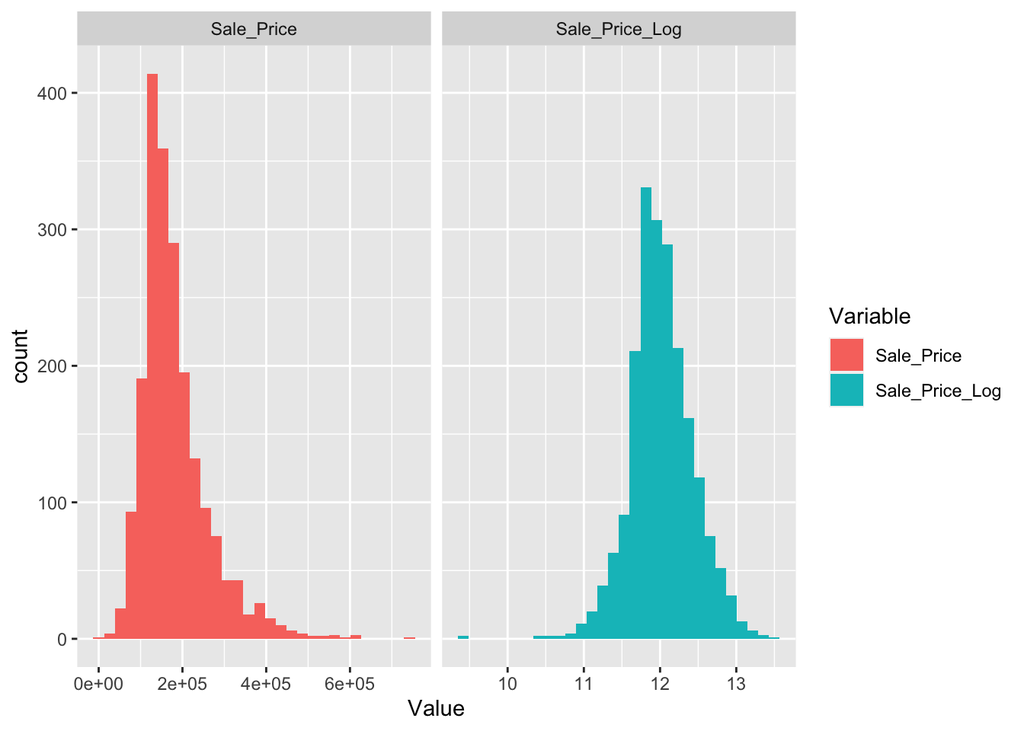

A log transformation won’t work if there are negative values. There are a few other altenratives that can be used in that case like displacing the distribution if the negative values are very small (greater than -0.99 say), or Box Cox transformation.

A log transformation can be implemented with the `recipes` package.

```r
ames_recipe <- recipes::recipe(
    Sale_Price ~ .,
    data = ames_train) %>%
    recipes::step_log(
        recipes::all_outcomes())

ames_recipe
```

### Dealing with missingness

Data can be missing for many reasons, that are usually grouped into two categories: *Informative missingness* and *missingness at random*.

Informative missingness implies a structural cause for the missing value that can provide insight in its own right, whether this be deficiencies in how the data was collected or abnormalities in the observational environment. We might give these values their own category as their unique value may affect predictive performance.

Missingness at random implies that missing values occur independent of the data collection process. These values might deserve deletion or imputation.

Moreover missingness is a problem for many models that cannot handle missingness.

### Visualising missing values

Missing values can be visualized easily with data transformation. The package `visdat` also includes functionality for this.

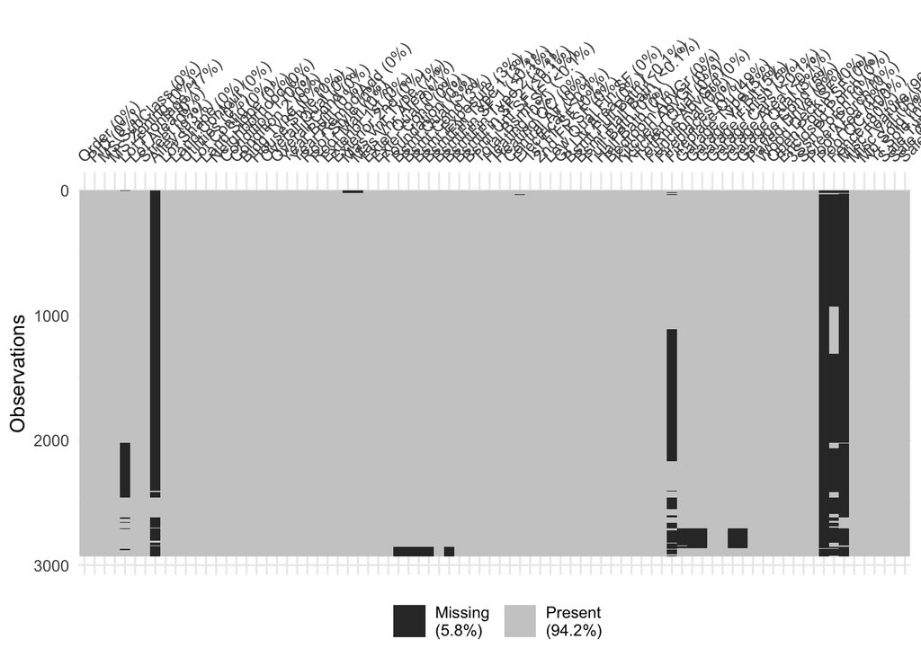

```r
visdat::vis_miss(AmesHousing::ames_raw, cluster = TRUE)
```

#### Imputation

Imputation is the process of replacing a missing value with a substituted, best guess value. This is one of the first feature engineering steps as it affects downstream processing.

The main options discussed in the text are imputation of a statistic such as mean or median, k-nearest neighbour or using a tree. The trade-off is usually computational effort and accuracy / complexity.

A critical aspect is that since imputation uses data from the set, it should always be used within the training set or the analysis set in the case of resampling.

```r
ames_recipe %>%
    recipes::step_impute_median(Gr_Liv_Area)

ames_recipe %>%
    recipes::step_impute_knn(
        recipes::all_predictors(),
        neighbors = 6)

ames_recipe %>%
    recipes::step_impute_bag(
        recipes::all_predictors())
```

### Feature filtering

There is a trade off between the number of features and the computational cost / easiness to interpret a model. Some models also show resistance to dealing with many features.

Even if some models are not affected in their predictive performance by non-informative predictors, the time to train and maintain this models can negatively impacted.

The first variables that should be removed are zero variance and near zero variance variables, which not bring significant information to the model.

```r
caret::nearZeroVar(
    ames_train,
    saveMetrics = TRUE) %>%
    rownames_to_column() %>%
    filter(nzv)
```

```
##               rowname  freqRatio percentUnique zeroVar  nzv
## 1              Street  226.66667    0.09760859   FALSE TRUE
## 2               Alley   24.25316    0.14641288   FALSE TRUE
## 3        Land_Contour   19.50000    0.19521718   FALSE TRUE
## 4           Utilities 1023.00000    0.14641288   FALSE TRUE
## 5          Land_Slope   22.15909    0.14641288   FALSE TRUE
## 6         Condition_2  202.60000    0.34163006   FALSE TRUE
## 7           Roof_Matl  144.35714    0.39043436   FALSE TRUE
## 8           Bsmt_Cond   20.24444    0.29282577   FALSE TRUE
## 9      BsmtFin_Type_2   25.85294    0.34163006   FALSE TRUE
## 10       BsmtFin_SF_2  453.25000    9.37042460   FALSE TRUE
## 11            Heating  106.00000    0.29282577   FALSE TRUE
## 12    Low_Qual_Fin_SF 1010.50000    1.31771596   FALSE TRUE
## 13      Kitchen_AbvGr   21.23913    0.19521718   FALSE TRUE
## 14         Functional   38.89796    0.39043436   FALSE TRUE
## 15     Enclosed_Porch  102.05882    7.41825281   FALSE TRUE
## 16 Three_season_porch  673.66667    1.12249878   FALSE TRUE
## 17       Screen_Porch  169.90909    4.63640800   FALSE TRUE
## 18          Pool_Area 2039.00000    0.53684724   FALSE TRUE
## 19            Pool_QC  509.75000    0.24402147   FALSE TRUE
## 20       Misc_Feature   34.18966    0.24402147   FALSE TRUE
## 21           Misc_Val  180.54545    1.56173743   FALSE TRUE
```

The same flow couyld be done using the tidymodels package.

```r
ames_recipe_01 <- ames_recipe %>%
    recipes::step_nzv(recipes::all_predictors())

ames_recipe_02 <- ames_recipe_01 %>%
    recipes::prep(retain = TRUE)

ames_recipe_02 %>%
    recipes::tidy()
```

```
## # A tibble: 2 × 6
##   number operation type  trained skip  id
##    <int> <chr>     <chr> <lgl>   <lgl> <chr>
## 1      1 step      log   TRUE    FALSE log_vkpTS
## 2      2 step      nzv   TRUE    FALSE nzv_7hjz1
```

```r
ames_recipe_02 %>%
    recipes::tidy(
        type = "nzv")
```

```
## # A tibble: 2 × 6
##   number operation type  trained skip  id
##    <int> <chr>     <chr> <lgl>   <lgl> <chr>
## 1      1 step      log   TRUE    FALSE log_vkpTS
## 2      2 step      nzv   TRUE    FALSE nzv_7hjz1
```

### Numeric feature engineering

For the same reasons discussed on the target variable, skewness, outliers, and extreme distributions might affect the performance of parametric models.

#### Skewness

Same transformations as before, Box Cox and YeoJohnson can be used on numeric features to remove skewness.

```r
recipes::recipe(
    Sale_Price ~ .,
    data = ames_train) %>%
    recipes::step_YeoJohnson(
        recipes::all_numeric())
```

#### Standardization

Since some models apply functions over their inputs, they might be sensible to the magnitude of these inputs. Centering and variance scaling help these models.

```r
ames_recipe %>%
    recipes::step_center(
        recipes::all_numeric()) %>%
    recipes::step_scale(
        recipes::all_numeric())
```

### Categorical feature engineering

Most models require that the predictors take numeric form. Moreover, manipulation on the categorical predictors might reduce the number of values and improving computational time, though sometimes at the expense of predictive performance.

#### Lumping

This is the practice of aggregating categories with very few categories together to create a new category which is more meaningful.

```r
ames_train %>%
    count(Neighborhood) %>%
    arrange(n)
```

```
## # A tibble: 28 × 2
##    Neighborhood            n
##    <fct>               <int>
##  1 Landmark                1
##  2 Green_Hills             2
##  3 Greens                  3
##  4 Blueste                 8
##  5 Veenker                15
##  6 Northpark_Villa        17
##  7 Bloomington_Heights    18
##  8 Meadow_Village         22
##  9 Briardale              23
## 10 Clear_Creek            26
## # ℹ 18 more rows
```

```r
lumping <- recipes::recipe(
    Sale_Price ~ .,
    data = ames_train) %>%
    recipes::step_other(
        Neighborhood,
        threshold = 0.01,
        other = "Other")

ames_train_lumping <- lumping %>%
    recipes::prep(
        training = ames_train) %>%
    recipes::bake(ames_train)

ames_train_lumping %>%
    count(Neighborhood) %>%
    arrange(n)
```

```
## # A tibble: 22 × 2
##    Neighborhood                                n
##    <fct>                                   <int>
##  1 Meadow_Village                             22
##  2 Briardale                                  23
##  3 Clear_Creek                                26
##  4 South_and_West_of_Iowa_State_University    32
##  5 Stone_Brook                                40
##  6 Northridge                                 51
##  7 Timberland                                 52
##  8 Other                                      64
##  9 Brookside                                  74
## 10 Crawford                                   75
## # ℹ 12 more rows
```

#### One-hot & dummy encoding

These are methods to transform categorical categories into numerical variables. One-hot transformation converts every category value into a less-than-full rank encoding, such as every value gets its own column, with a value of `1` if the observation has that value, or `0` otherwise.

Since this introduces colinearity and this is a problem for some models, an alternative encoding is dummy encoding, that removes one column from the one-hot encoding.

```r
recipes::recipe(
    Sale_Price ~ .,
    data = ames_train) %>%
    recipes::step_dummy(
        all_nominal(),
        one_hot = TRUE)
```

#### Label encoding

Dummy encoding creates new variables, that increase the dimensionality of the datasets. Label encoding instead transforms categories into numerical variables without increasing dimensionality. However this numerical transformation introduces an ordering to the feature.

```r
ames_train %>%
    count(MS_SubClass)
```

```
## # A tibble: 15 × 2
##    MS_SubClass                                   n
##    <fct>                                     <int>
##  1 One_Story_1946_and_Newer_All_Styles         756
##  2 One_Story_1945_and_Older                     94
##  3 One_Story_with_Finished_Attic_All_Ages        4
##  4 One_and_Half_Story_Unfinished_All_Ages       13
##  5 One_and_Half_Story_Finished_All_Ages        203
##  6 Two_Story_1946_and_Newer                    404
##  7 Two_Story_1945_and_Older                     90
##  8 Two_and_Half_Story_All_Ages                  14
##  9 Split_or_Multilevel                          85
## 10 Split_Foyer                                  37
## 11 Duplex_All_Styles_and_Ages                   76
## 12 One_Story_PUD_1946_and_Newer                132
## 13 Two_Story_PUD_1946_and_Newer                 86
## 14 PUD_Multilevel_Split_Level_Foyer             12
## 15 Two_Family_conversion_All_Styles_and_Ages    43
```

```r
ames_train %>%
    recipes::recipe(
        Sale_Price ~ .) %>%
    recipes::step_integer(
        MS_SubClass) %>%
    recipes::prep(
        ames_train) %>%
    recipes::bake(
        ames_train) %>%
    count(MS_SubClass)
```

```
## # A tibble: 15 × 2
##    MS_SubClass     n
##          <int> <int>
##  1           1   756
##  2           2    94
##  3           3     4
##  4           4    13
##  5           5   203
##  6           6   404
##  7           7    90
##  8           8    14
##  9           9    85
## 10          10    37
## 11          11    76
## 12          12   132
## 13          14    86
## 14          15    12
## 15          16    43
```

### Dimension reduction

Dimension reduction is an alternative to filter out non-informative features.

```r
ames_train %>%
    recipes::recipe(
        Sale_Price ~ .) %>%
    recipes::step_center(
        recipes::all_numeric()) %>%
    recipes::step_scale(
        recipes::all_numeric()) %>%
    recipes::step_pca(
        recipes::all_numeric(),
        threshold = 0.95)
```

### Proper implementation

Feature engineering should be though of as a blueprint to apply over the data (which is aligned with the metaphor used in the `recipes` package). This has two advantages, thinking sequentially and to apply appropriately within the resampling process.

#### Sequential steps

There are some general suggestions to follow when doing feature engineering.

- If using a log or Box-Cox transformation, don’t do any operations that might make the data non-positive.
- Dummy encoding results in sparse data which many algorithms can operate efficiently on. Standardization has the result of creating dense data instead. Standardization is usually preferred before dummy encoding.
- Lumping is better to be done before dummy encoding.
- Dimension reduction is commonly done on numeric features.

A suggested order of potential steps that usually work for most problems are:

1. Filter out zero or near-zero variance features.
2. Perform imputation if required.
3. Normalize to resolve numeric feature skewness.
4. Standardize (center and scale) numeric features.
5. Perform dimension reduction (e.g. PCA) on numeric features.
6. Dummy (unordereed) or label (ordered) encode categorical features.

#### Data leakage

In order to avoid data leakage, feature engineering should be done in every resampling set.

#### Putting the process together

We first create a blueprint (recipe) with all the steps we want to apply on the data.

```r
blueprint <-
    ames_train %>%
    recipes::recipe(
        Sale_Price ~ .) %>%
    recipes::step_nzv(
        recipes::all_nominal()) %>%
    recipes::step_integer(
        matches(
            "Qual|Cond|QC|Qu")) %>%
    recipes::step_center(
        recipes::all_numeric(),
        - recipes::all_outcomes()) %>%
    recipes::step_scale(
        recipes::all_numeric(),
        - recipes::all_outcomes()) %>%
    recipes::step_dummy(
        recipes::all_nominal(),
        - recipes::all_outcomes(),
        one_hot = TRUE)
```

These steps are just a specification, but in order to apply some of the steps, there are some statistics that need to be calculated over the actual dataset. These are calculated with the `prep` function.

```r
prepare <-
    blueprint %>%
    recipes::prep(training = ames_train)
```

Finally the full transformation can be applied over the test and training datasets using the `bake` function.

```r
baked_train <- prepare %>%
    recipes::bake(
        new_data = ames_train)

baked_test <- prepare %>%
    recipes::bake(
        new_data = ames_test)
```

The (old) `caret` packages allows to explore a whole model tuning process. For instance:

- Try the k-nearest neighbor model over the `ames` dataset.
- Explore what’s the hyper-parameter `k` with the best result.
- Do this over a cross-validation set, before going to the test data.
- Take into account the previous blueprint transformations for mdoel efficiency.

```r
cv <- caret::trainControl(
    method = "repeatedcv",
    number = 10,
    repeats = 5)

hyper_grid <- expand.grid(
    k = seq(2, 25, by = 1))

knn_fit <- caret::train(
    blueprint,
    data = ames_train,
    method = "knn",
    trControl = cv,
    tuneGrid = hyper_grid,
    metric = "RMSE")

knn_fit
```

```
## k-Nearest Neighbors
##
## 2049 samples
##   80 predictor
##
## Recipe steps: nzv, integer, center, scale, dummy
## Resampling: Cross-Validated (10 fold, repeated 5 times)
## Summary of sample sizes: 1844, 1844, 1844, 1843, 1844, 1845, ...
## Resampling results across tuning parameters:
##
##   k   RMSE      Rsquared   MAE
##    2  35597.93  0.8101212  22846.37
##    3  34905.78  0.8201483  22133.28
##    4  34784.38  0.8239227  21763.33
##    5  34629.61  0.8288092  21568.04
##    6  34273.28  0.8343168  21267.81
##    7  34084.96  0.8376015  21134.25
##    8  33785.77  0.8415465  20991.30
##    9  33698.64  0.8431652  20921.16
##   10  33654.03  0.8441192  20889.79
##   11  33702.84  0.8446912  20972.06
##   12  33762.01  0.8449624  21009.64
##   13  33896.74  0.8446195  21159.00
##   14  34032.38  0.8436117  21240.90
##   15  34175.57  0.8426930  21298.78
##   16  34290.82  0.8422735  21362.51
##   17  34423.65  0.8414885  21430.68
##   18  34523.20  0.8410549  21498.77
##   19  34572.73  0.8409980  21539.46
##   20  34656.87  0.8405035  21576.13
##   21  34690.50  0.8407347  21611.78
##   22  34728.62  0.8408120  21656.06
##   23  34827.04  0.8404467  21707.69
##   24  34928.26  0.8398138  21756.79
##   25  35001.41  0.8396147  21806.56
##
## RMSE was used to select the optimal model using the smallest value.
## The final value used for the model was k = 10.
```